# Top Ten R Tips & Tricks

Heather Lendway

### *1. The Pipe “%>%”*

Hopefully as R users you are familiar with the pipe - “%>%”. You can use the pipe to pass your results into the next command without having to save your data to many intermediary variables. The short cut for typing the pipe “%>%” quickly is **ctrl + shift + m**. If you’re not already using this shortcut it will definitely speed up your coding process!

```r
# This code...
no_sepal_length <- select(iris, -Sepal.Length)
iris_with_ratio <- mutate(no_sepal_length, petal.ratio = Petal.Length/Petal.Width)
filtered_iris <- filter(iris_with_ratio, Species == "setosa")

# ...turns into this code
new_iris <- iris %>%
  select(-Sepal.Length) %>%
  mutate(petal.ratio = Petal.Length/Petal.Width) %>%
  filter(Species == "setosa")
```

### *2. The backtick `*

The difference between the backtick ` and apostrophe ’ is very subtle visually but the difference is significant in R. To reference a column name with spaces or a reserved word, in many cases you must use backticks. For the sample below I added a column called “new col”. If I try to filter on the values of “new col” the filter doesn’t work, but when I use `new col` it works. If you end up with a reserved word like NA, NULL or if as a column name, you would also need to reference them with the backtick `.

With the quotes are “new col”, it’s recognized as a string instead of the column name.

```r
iris %>%
  filter('new col' > 10) %>%
  slice(1:10)
```

```
##    Sepal.Length Sepal.Width Petal.Length Petal.Width Species new col test1
## 1           5.1         3.5          1.4         0.2  setosa    10.2    NA
## 2           4.9         3.0          1.4         0.2  setosa     9.8    NA
## 3           4.7         3.2          1.3         0.2  setosa     9.4    NA
## 4           4.6         3.1          1.5         0.2  setosa     9.2    NA
## 5           5.0         3.6          1.4         0.2  setosa    10.0    NA
## 6           5.4         3.9          1.7         0.4  setosa    10.8    NA
## 7           4.6         3.4          1.4         0.3  setosa     9.2    NA
## 8           5.0         3.4          1.5         0.2  setosa    10.0    NA
## 9           4.4         2.9          1.4         0.2  setosa     8.8    NA
## 10          4.9         3.1          1.5         0.1  setosa     9.8    NA
##    test2 test3  percent
## 1     NA    NA 1.457143
## 2     NA   4.9 1.633333
## 3     NA   4.7 1.468750
## 4     NA   4.6 1.483871
## 5     NA   5.0 1.388889
## 6     NA    NA 1.384615
## 7     NA   4.6 1.352941
## 8     NA   5.0 1.470588
## 9     NA   4.4 1.517241
## 10    NA   4.9 1.580645
```

```r
iris %>%
  filter(`new col` > 10) %>%
  slice(1:10)
```

```
##    Sepal.Length Sepal.Width Petal.Length Petal.Width Species new col test1
## 1           5.1         3.5          1.4         0.2  setosa    10.2    NA
## 2           5.4         3.9          1.7         0.4  setosa    10.8    NA
## 3           5.4         3.7          1.5         0.2  setosa    10.8    NA
## 4           5.8         4.0          1.2         0.2  setosa    11.6    NA
## 5           5.7         4.4          1.5         0.4  setosa    11.4    NA
## 6           5.4         3.9          1.3         0.4  setosa    10.8    NA
## 7           5.1         3.5          1.4         0.3  setosa    10.2    NA
## 8           5.7         3.8          1.7         0.3  setosa    11.4    NA
## 9           5.1         3.8          1.5         0.3  setosa    10.2    NA
## 10          5.4         3.4          1.7         0.2  setosa    10.8    NA
##    test2 test3  percent
## 1     NA    NA 1.457143
## 2     NA    NA 1.384615
## 3     NA    NA 1.459459
## 4     NA    NA 1.450000
## 5     NA    NA 1.295455
## 6     NA    NA 1.384615
## 7     NA    NA 1.457143
## 8     NA    NA 1.500000
## 9     NA    NA 1.342105
## 10    NA    NA 1.588235
```

As a side note, if you do have a file with long column titles with spaces, I recommend using the janitor package to quick clean up your column names for coding sake.

```r
iris %>%
  clean_names() %>%
  slice(1:10)
```

```
##    sepal_length sepal_width petal_length petal_width species new_col test1
## 1           5.1         3.5          1.4         0.2  setosa    10.2    NA
## 2           4.9         3.0          1.4         0.2  setosa     9.8    NA
## 3           4.7         3.2          1.3         0.2  setosa     9.4    NA
## 4           4.6         3.1          1.5         0.2  setosa     9.2    NA
## 5           5.0         3.6          1.4         0.2  setosa    10.0    NA
## 6           5.4         3.9          1.7         0.4  setosa    10.8    NA
## 7           4.6         3.4          1.4         0.3  setosa     9.2    NA
## 8           5.0         3.4          1.5         0.2  setosa    10.0    NA
## 9           4.4         2.9          1.4         0.2  setosa     8.8    NA
## 10          4.9         3.1          1.5         0.1  setosa     9.8    NA
##    test2 test3  percent
## 1     NA    NA 1.457143
## 2     NA   4.9 1.633333
## 3     NA   4.7 1.468750
## 4     NA   4.6 1.483871
## 5     NA   5.0 1.388889
## 6     NA    NA 1.384615
## 7     NA   4.6 1.352941
## 8     NA   5.0 1.470588
## 9     NA   4.4 1.517241
## 10    NA   4.9 1.580645
```

### *3. Remove or Select NA/NULL Columns*

When working with large data sets you may find that entire columns of data are NULL or NA. You may want to quickly clean up your data so you’re only dealing with values you care about or maybe you want to quick validate you’re actually getting the data you expect in a column. You can quickly get rid of all the NULL/NA columns or select them all to ensure you’re not missing something. To do this in R we will use the select_if command with is.na() and is.null() which evalute to TRUE/1 and FALSE/0. Summing not na or null for the column will be zero if every row is na or null and greater than zero if there is a value in at least one row in the column.

Here you can see we have kept all columns that have some values in them.

```r
iris %>%
  #added vars to help see what select_if is doing, test2 is removed, test3 is not
  mutate(na_or_null_t2 = (is.na(test2)|is.null(test2)),
         na_or_null_t3 = (is.na(test3)|is.null(test3))) %>%
  select_if(~sum(!(is.na(.)|is.null(.))) > 0) %>%
  slice(1:10) %>%
  select(-Sepal.Length) #just to show test3 with NA's
```

```
##    Sepal.Width Petal.Length Petal.Width Species new col test3  percent
## 1          3.5          1.4         0.2  setosa    10.2    NA 1.457143
## 2          3.0          1.4         0.2  setosa     9.8   4.9 1.633333
## 3          3.2          1.3         0.2  setosa     9.4   4.7 1.468750
## 4          3.1          1.5         0.2  setosa     9.2   4.6 1.483871
## 5          3.6          1.4         0.2  setosa    10.0   5.0 1.388889
## 6          3.9          1.7         0.4  setosa    10.8    NA 1.384615
## 7          3.4          1.4         0.3  setosa     9.2   4.6 1.352941
## 8          3.4          1.5         0.2  setosa    10.0   5.0 1.470588
## 9          2.9          1.4         0.2  setosa     8.8   4.4 1.517241
## 10         3.1          1.5         0.1  setosa     9.8   4.9 1.580645
##    na_or_null_t2 na_or_null_t3
## 1           TRUE          TRUE
## 2           TRUE         FALSE
## 3           TRUE         FALSE
## 4           TRUE         FALSE
## 5           TRUE         FALSE
## 6           TRUE          TRUE
## 7           TRUE         FALSE
## 8           TRUE         FALSE
## 9           TRUE         FALSE
## 10          TRUE         FALSE
```

Here you can see we have kept all columns that are only NA, this can be useful to quickly pick out if some data is missing.

```r
iris %>%
  select_if(~sum(!(is.na(.)|is.null(.))) == 0) %>%
  slice(1:10)
```

```
##    test1 test2
## 1     NA    NA
## 2     NA    NA
## 3     NA    NA
## 4     NA    NA
## 5     NA    NA
## 6     NA    NA
## 7     NA    NA
## 8     NA    NA
## 9     NA    NA
## 10    NA    NA
```

### *4. fct_recode*

If you’ve worked with R for a while, you’re like familiar with the data type “Factor”. Factors can be complicated but the forcats (factors rearranged) package has a lot of useful functions to make dealing with factors a lot easier. One function I find myself using again and again is fct_recode. This allows you to change the name of the factor level, therefore updating the all occurences of that factor to the new value. Without changing the level name, you’re only changing the value you see in your table, which may cause issues down the line.

This first example shows how you might want to change a level but it doesn’t work as you’d expect.

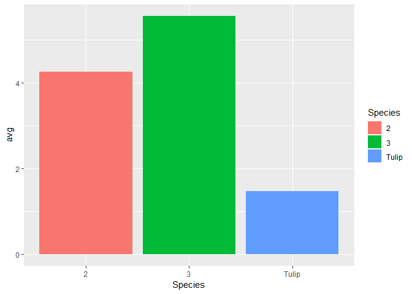

```r
# You can check a class of a var using "class" - class(iris$Species) - or in the Environment tab

iris2 <- iris %>%
  mutate(Species = ifelse((Species=="setosa"),"Tulip",Species))

iris2 %>%
  group_by(Species) %>%
  summarise(avg = mean(Petal.Length)) %>%
  ggplot(aes(x=Species,y=avg,fill=Species)) +
  geom_bar(stat="identity")
```

In the next example you can see using fct_recode(col_name,“new_value”=“old_value”) will properly update the factor levels.

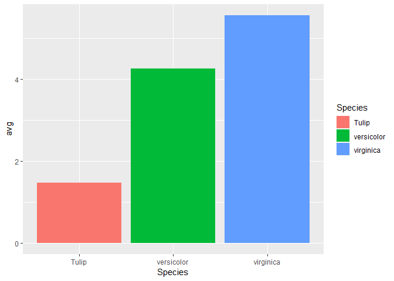

```r
iris3 <- iris %>%
  mutate(Species = fct_recode(Species,"Tulip"="setosa"))

iris3 %>%
  group_by(Species) %>%
  summarise(avg = mean(Petal.Length)) %>%
  ggplot(aes(x=Species,y=avg,fill=Species)) +
  geom_bar(stat="identity")
```

### *5. rename, replace_na*

Another set of functions that I often use are “rename” and “replace_na”. Rename allows you to easily rename a column, and replace_na is a quick way to replace all na values in a list. Below you can see the syntax for each.

- replace_na(list(col_name=replacement_value,col_name2=replacement_value2,…))
- rename(new_col_name=old_col_name,new_col_name2=old_col_name2,…)

```r
iris %>%
  replace_na(list(test3=0)) %>%
  rename(my_new_col=test3) %>%
  select(5:10) %>%
  slice(1:10)
```

```
##    Species new col test1 test2 my_new_col  percent
## 1   setosa    10.2    NA    NA        0.0 1.457143
## 2   setosa     9.8    NA    NA        4.9 1.633333
## 3   setosa     9.4    NA    NA        4.7 1.468750
## 4   setosa     9.2    NA    NA        4.6 1.483871
## 5   setosa    10.0    NA    NA        5.0 1.388889
## 6   setosa    10.8    NA    NA        0.0 1.384615
## 7   setosa     9.2    NA    NA        4.6 1.352941
## 8   setosa    10.0    NA    NA        5.0 1.470588
## 9   setosa     8.8    NA    NA        4.4 1.517241
## 10  setosa     9.8    NA    NA        4.9 1.580645
```

### *6. R Notebooks or Markdown*

R markdown allows you to easily make your code output something you can share. As data changes your markdown can redo all calculations and update the output with the up to date values. You can style your output and easily include calculated values directly in your text. For example, I can directly add the count of rows in a dataset into my text: there are 50 setosa species in the iris data set (view the code in the markdown file). You can “knit” your document to html, pdf or word, I prefer the flexibility of html (this document is written in Rmarkdown, knit to html) .

You can also easily insert formulas into your text and they’re formated nicely. The likelihood function for logistic regression: $\prod_{i=1}^n p_i^{y_i}(1-p_i)^{1-y_i}$

You can also apply corporate digital styling to your template to share the company look and feel and color pallete.

### *7. Filter with str_detect*

Many of the functions in the stringr package allow you to use regular expressions to search for string patterns. The ability to filter using regular expressions can be very powerful. Below is a simple example.

Here I want to pull out all the rows of data related to film that had a 60 inch width, which is designated ‘60 IN’ in some cases and ‘60"’ in others. Using a regular expressiong with str_detect, you can filter to get only the rows you want. Read more about the stringr package and regex [here](https://stringr.tidyverse.org/articles/regular-expressions.html#escaping).

```r
test_data %>%
  select(3:5) %>%
  slice(1:10)
```

```
##    overall_usd_value selling_country
## 1            1189.68   United States
## 2            1296.70   United States
## 3            1189.68   United States
## 4            1903.22   United States
## 5              52.29   United States
## 6            1189.68   United States
## 7            1406.70   United States
## 8               0.00   United States
## 9               0.00   United States
## 10           1146.26             N/A
##                                                                                                                                         item_description
## 1  3M(TM) BASE STATION,WITHOUT POWER SUPPLY -3MID- 78691150680                                                                                 126511662
## 2  3M(TM) DRIVE-THRU BASESTATION G5 -3MID- 78811746839                                                                                         129491358
## 3  3M(TM) BASE STATION,WITHOUT POWER SUPPLY -3MID- 78691150680                                                                                 126511662
## 4  3M(TM) DRIVE-THRU BASESTATION G5 DUAL LANE 2.4 WITHOUT POWER S -3MID- 78811746847                                                           131842562
## 5  3000 MEDIUM DUTY SPONGE SCRUBBER                       20/CASE -3MID- 70071285269                                                           106967116
## 6  3M(TM) BASE STATION,WITHOUT POWER SUPPLY -3MID- 78691150680                                                                                 126511662
## 7  3M(TM) HEADSET WITHOUT BATTERY -3MID- 78691150979                                                                                           128026180
## 8  LX480MC PRINT WRAP FILM SF 60INX50YD -3MID- 75347288930                                                                                     131419711
## 9  40C-10R PRINT FILM SF 54INX50YD -3MID- 75347273056                                                                                          129898827
## 10 IJ 180 CV3-10 WHITE            1372mm x 50m -3MID- DR305010040                                                                              130611195
```

```r
test_data %>%
  filter(str_detect(item_description,"60\"|60 IN")) %>%
  select(item_description) %>%
  slice(1:10)
```

```
##                                                                                                                                         item_description
## 1  imported logroll RE70film 60" X 100LNFT -3MID- 11400143233                                                                                  128365496
## 2  imported logroll RE70film 60" X 100LNFT -3MID- 11400143233                                                                                  128365496
## 3   FX ST 35 60 IN X  100 FT BULK -3MID- 70006344124                                                                                            98708677
## 4  BC 10 (M) 60 IN X 100 FT -3MID- 70006349180                                                                                                 105319196
## 5  SC IJ 25-10R 60" X 100M -3MID- DR500010332                                                                                                  108708244
## 6  LOW-E 35 60 IN X 100 FT -3MID- 70006794070                                                                                                  130998435
## 7  FX ST 5 (M) 60 IN X 100 FT -3MID- 70006344504                                                                                               103291674
## 8  FX ST 5 (M) 60 IN X 100 FT -3MID- 70006344504                                                                                               103291674
## 9  FX ST 5 (M) 60 IN X 100 FT -3MID- 70006344504                                                                                               103291674
## 10 FX ST 5 (M) 60 IN X 100 FT -3MID- 70006344504                                                                                               103291674
```

To take it one step further, you could also create a new variable using regex to pull out the width unit.

```r
test_data %>%
  mutate(measurement = if_else((str_detect(item_description,"[0-9]+\"|[0-9]+ IN")),"Inches",
                               if_else((str_detect(item_description,"[0-9]+mm|[0-9]+MM")),"MM","Unknown"))) %>%
  select(5:6) %>%
  slice(1:30)
```

```
##                                                                                                                                         item_description
## 1  3M(TM) BASE STATION,WITHOUT POWER SUPPLY -3MID- 78691150680                                                                                 126511662
## 2  3M(TM) DRIVE-THRU BASESTATION G5 -3MID- 78811746839                                                                                         129491358
## 3  3M(TM) BASE STATION,WITHOUT POWER SUPPLY -3MID- 78691150680                                                                                 126511662
## 4  3M(TM) DRIVE-THRU BASESTATION G5 DUAL LANE 2.4 WITHOUT POWER S -3MID- 78811746847                                                           131842562
## 5  3000 MEDIUM DUTY SPONGE SCRUBBER                       20/CASE -3MID- 70071285269                                                           106967116
## 6  3M(TM) BASE STATION,WITHOUT POWER SUPPLY -3MID- 78691150680                                                                                 126511662
## 7  3M(TM) HEADSET WITHOUT BATTERY -3MID- 78691150979                                                                                           128026180
## 8  LX480MC PRINT WRAP FILM SF 60INX50YD -3MID- 75347288930                                                                                     131419711
## 9  40C-10R PRINT FILM SF 54INX50YD -3MID- 75347273056                                                                                          129898827
## 10 IJ 180 CV3-10 WHITE            1372mm x 50m -3MID- DR305010040                                                                              130611195
## 11 CT 180-3006 VHC red 1220mm x 50m -3MID- DY304300600                                                                                         129327731
## 12 SG 8993 TRANSPARENT            1220mm x 50m -3MID- DR330639003                                                                              131174431
## 13  3M NOMAD 8100 UNBKD DARK BLUE 4FT X 20FT  1/CS -3MID- 70071005261                                                                           86185329
## 14 3M SILVER 15 EXTERIOR          72" x 100FT -3MID- DE272925186                                                                               131174486
```

[output cut: 47 more lines]

### *8. Group By & Filter*

Typically when using a group by function the next step would likely be some sort of summarization. In R you can actually group your data and use summary functions right in the filter. An example demonstrates the power of this. Say I have a set of sales related data for each country and I want to only look at the data for those countries with more than 50 sales records for the year.

```r
test_data %>%
  select(1:4) %>%
  slice(1:10)
```

```
##    created_year created_month overall_usd_value selling_country
## 1          2017             7           1189.68   United States
## 2          2017            10           1296.70   United States
## 3          2017            11           1189.68   United States
## 4          2017            11           1903.22   United States
## 5          2017            12             52.29   United States
## 6          2017            12           1189.68   United States
## 7          2017            12           1406.70   United States
## 8          2017            12              0.00   United States
## 9          2017            12              0.00   United States
## 10         2017             9           1146.26             N/A
```

The first chunk of code is how I would typically think of this problem.

```r
test_data %>%
  group_by(selling_country,created_year) %>%
  mutate(count = n()) %>%
  filter(count > 50) %>%
  select(1:4) %>%
  slice(1:10)
```

```
## # A tibble: 140 x 4
## # Groups:   selling_country, created_year [14]
##    created_year created_month overall_usd_value selling_country
##           <int>         <int>             <dbl> <fct>
##  1         2017            12             140.  Australia
##  2         2017             5              81.2 Australia
##  3         2017             5              22.1 Australia
##  4         2017             6             666.  Australia
##  5         2017             7             338.  Australia
##  6         2017             7            1043.  Australia
##  7         2017             7             332.  Australia
##  8         2017             8             120.  Australia
##  9         2017             8             417.  Australia
## 10         2017             8            1422.  Australia
## # ... with 130 more rows
```

This next set of code demonstrates the alternative by using a summarise funtion within the filter. It saves a line of code and there’s no need to create an actual count variable. Other summary functions you could use, sum(),n_distinct(),mean(),min(),max(),… and many more.

```r
test_data %>%
  group_by(selling_country,created_year) %>%
  filter(n() > 50) %>%
  select(1:4) %>%
  slice(1:10)
```

```
## # A tibble: 140 x 4
## # Groups:   selling_country, created_year [14]
##    created_year created_month overall_usd_value selling_country
##           <int>         <int>             <dbl> <fct>
##  1         2017            12             140.  Australia
##  2         2017             5              81.2 Australia
##  3         2017             5              22.1 Australia
##  4         2017             6             666.  Australia
##  5         2017             7             338.  Australia
##  6         2017             7            1043.  Australia
##  7         2017             7             332.  Australia
##  8         2017             8             120.  Australia
##  9         2017             8             417.  Australia
## 10         2017             8            1422.  Australia
## # ... with 130 more rows
```

### *9. Spread & Gather*

The above commands are a very powerful set of commands for reshaping your data. Spread and gather will pivot your existing data into a wide and narrow format respetively.

Let’s say I want to compare sales year over year by month for any country with over 50 sales.

```r
# first summarise the data and get a total for each year and month
step1 <- test_data2 %>%
  group_by(selling_country) %>%
  filter(n() > 50) %>%
  group_by(selling_country,created_year,created_month) %>%
  summarise(total_usd = sum(overall_usd_value))

step1 %>%
  slice(1:10)
```

```
## # A tibble: 421 x 4
## # Groups:   selling_country, created_year [81]
##    selling_country created_year created_month total_usd
##    <fct>                  <int>         <int>     <dbl>
##  1 Australia               2016            11     363.
##  2 Australia               2017             5     103.
##  3 Australia               2017             6     667.
##  4 Australia               2017             7    1712.
##  5 Australia               2017             8    2800.
##  6 Australia               2017             9      16.3
##  7 Australia               2017            10    1412.
##  8 Australia               2017            11    6574.
##  9 Australia               2017            12   24385
## 10 Australia               2018             1   15544.
## # ... with 411 more rows
```

```r
# now use spread to create the table with a row for year year, fill with 0
step2 <- step1 %>%
  group_by(selling_country,created_year) %>%
  spread(created_month,total_usd, fill = 0)

step2 %>%
  slice(1:10)
```

```
## # A tibble: 81 x 14
## # Groups:   selling_country, created_year [81]
##    selling_country created_year    `1`    `2`    `3`    `4`    `5`   `6`
##    <fct>                  <int>  <dbl>  <dbl>  <dbl>  <dbl>  <dbl> <dbl>
##  1 Australia               2016     0      0      0      0      0     0
##  2 Australia               2017     0      0      0      0    103.  667.
##  3 Australia               2018 15544. 71226. 32613. 19195. 17107. 9548.
##  4 Austria                 2007     0      0      0      0      0   705.
##  5 Austria                 2008     0      0      0      0      0     0
##  6 Austria                 2009     0      0      0      0      0     0
##  7 Austria                 2011     0      0      0      0      0     0
##  8 Austria                 2012     0      0      0      0      0     0
##  9 Austria                 2013     0      0      0      0      0     0
## 10 Austria                 2014     0      0      0      0      0     0
## # ... with 71 more rows, and 6 more variables: `7` <dbl>, `8` <dbl>,
## #   `9` <dbl>, `10` <dbl>, `11` <dbl>, `12` <dbl>
```

```r
# Use gather to to go back to a narrow format (which also creates a "complete" data set).
step3 <- step2 %>%
  group_by(selling_country,created_year) %>%
  gather("month","usd",3:14) %>%
  arrange(selling_country,created_year,month)

step3 %>%
  slice(1:10)
```

```
## # A tibble: 810 x 4
## # Groups:   selling_country, created_year [81]
##    selling_country created_year month   usd
##    <fct>                  <int> <chr> <dbl>
##  1 Australia               2016 1        0
##  2 Australia               2016 10       0
##  3 Australia               2016 11     363.
##  4 Australia               2016 12       0
##  5 Australia               2016 2        0
##  6 Australia               2016 3        0
##  7 Australia               2016 4        0
##  8 Australia               2016 5        0
##  9 Australia               2016 6        0
## 10 Australia               2016 7        0
## # ... with 800 more rows
```

### *10. Unite & Seperate*

You can use unite and separate to collapse or expand serveral columns into one column or one column into many, and it allows you to specify the seperating string. These commands can be quite powerful when paired with some of the commands from above.

In this case “item descripton” actually contains a few things, item description, item dimension, and id numbers. Let’s say we want to pull out the item ID.

```r
sep_data <- test_data2 %>%
  separate(item_description, into = c("item_description", "3MID"), sep = " -3MID- ", drop = TRUE) %>%
  separate(`3MID`, into = c("product_code", "sku"), drop = TRUE)
sep_data %>%
  select(5:7) %>%
  slice(1:10)
```

```
##                                                  item_description
## 1                        3M(TM) BASE STATION,WITHOUT POWER SUPPLY
## 2                                3M(TM) DRIVE-THRU BASESTATION G5
## 3                        3M(TM) BASE STATION,WITHOUT POWER SUPPLY
## 4  3M(TM) DRIVE-THRU BASESTATION G5 DUAL LANE 2.4 WITHOUT POWER S
## 5  3000 MEDIUM DUTY SPONGE SCRUBBER                       20/CASE
## 6                        3M(TM) BASE STATION,WITHOUT POWER SUPPLY
## 7                                  3M(TM) HEADSET WITHOUT BATTERY
## 8                            LX480MC PRINT WRAP FILM SF 60INX50YD
## 9                                 40C-10R PRINT FILM SF 54INX50YD
## 10                        1080-M261 MATTE 60 IN X 25 YDSDARK GRAY
##    product_code       sku
## 1   78691150680 126511662
## 2   78811746839 129491358
## 3   78691150680 126511662
## 4   78811746847 131842562
## 5   70071285269 106967116
## 6   78691150680 126511662
## 7   78691150979 128026180
## 8   75347288930 131419711
## 9   75347273056 129898827
## 10  75347218531 127199764
```

In the next step, I’ll use unite to get my unique list of product combinations.

```r
unite_data <- sep_data %>%
  unite("3MID", 6:7, sep = "-", remove = TRUE)

unite_data %>%
  select(5:6) %>%
  slice(1:10)
```

```
##                                                  item_description
## 1                        3M(TM) BASE STATION,WITHOUT POWER SUPPLY
## 2                                3M(TM) DRIVE-THRU BASESTATION G5
## 3                        3M(TM) BASE STATION,WITHOUT POWER SUPPLY
## 4  3M(TM) DRIVE-THRU BASESTATION G5 DUAL LANE 2.4 WITHOUT POWER S
## 5  3000 MEDIUM DUTY SPONGE SCRUBBER                       20/CASE
## 6                        3M(TM) BASE STATION,WITHOUT POWER SUPPLY
## 7                                  3M(TM) HEADSET WITHOUT BATTERY
## 8                            LX480MC PRINT WRAP FILM SF 60INX50YD
## 9                                 40C-10R PRINT FILM SF 54INX50YD
## 10                        1080-M261 MATTE 60 IN X 25 YDSDARK GRAY
##                     3MID
## 1  78691150680-126511662
## 2  78811746839-129491358
## 3  78691150680-126511662
## 4  78811746847-131842562
## 5  70071285269-106967116
## 6  78691150680-126511662
## 7  78691150979-128026180
## 8  75347288930-131419711
## 9  75347273056-129898827
## 10 75347218531-127199764
```